# Project: Investigate a Dataset (Gun_census_NICS_data)

- Introduction
- Data Wrangling
- Exploratory Data Analysis
- Conclusions

## Introduction

**For this project I have chosen to investigate the excerpted data from the FBI's National Instant Criminal Background Check System (NICS) along with the supplemental Census population data by state. Federal law requires that Federal Firearm License (FFL) sellers to run background checks on prospective buyers through the NICS after it became operational in 1998. The NICS provides background check data for the purchase/transfer of both handguns and long guns (rifles) to eligible persons. Per Federal law, the FBI has 3 business days to allow or deny the transfer; after which the FFL may legally proceed with the transfer.**  
NICS Notes: via Wikipedia, fbi.gov

- "Most checks are determined within minutes. If a determination is not obtained within three business days then the transfer may legally be completed."
- "Background checks are not required under federal law for intrastate firearm transfers between private parties."
- "States may implement their own NICS programs. Such states become the point of contact (POC) between their FFL dealers and the NICS. A few partial-POC states run FFL handgun checks, while the FBI runs long gun checks."
- "NICS is located at the FBI’s Criminal Justice Information Services Division in Clarksburg, West Virginia. It provides full service to FFLs in 30 states, five U.S. territories, and the District of Columbia" **does this jive with data? looks like all 50 states are included in NICS gun_data**  
  **Gun rights, control and regulation are a collection of extremely divise topics in the United States today. The implementation of Federal legislation, such as the requirement for background checks and the NICS system of databases, are often at odds with state regulations that either seek to ease restrictions around gun ownership or provide for better enforcement of existing regulations. For this and other reasons there exists a broad spectrum of policies at the state level that contribute to the politics at play. In this exploratory data analysis I will examine data from a subset of the larger United States. These states come from either end of the gun control debate with laws and regulations that seek to either ensure a strict interpretation of the US Constitution's 2nd Amendment or provide for a modern regulatory framework that limits the ownership and transfer of firearms.**

```python
import pandas as pd
import numpy as np
import matplotlib.pyplot as plt
import seaborn as sns
# Remember to include a 'magic word' so that your visualizations are plotted
#  inline with the notebook. See this page for more: http://ipython.readthedocs.io/en/stable/interactive/magics.html
% matplotlib inline
```

## Data Wrangling

Load and check out the initial `census.csv` file.

```python
# Load your data and print out a few lines. Perform operations to inspect data
#   types and look for instances of missing or possibly errant data.
df_census = pd.read_csv('us_census_data.csv')
df_census.head()
```

|  | Fact | Fact Note | Alabama | Alaska | Arizona | Arkansas | California | Colorado | Connecticut | Delaware | ... | South Dakota | Tennessee | Texas | Utah | Vermont | Virginia | Washington | West Virginia | Wisconsin | Wyoming |
| --- | --- | --- | --- | --- | --- | --- | --- | --- | --- | --- | --- | --- | --- | --- | --- | --- | --- | --- | --- | --- | --- |
| 0 | Population estimates, July 1, 2016, (V2016) | NaN | 4,863,300 | 741,894 | 6,931,071 | 2,988,248 | 39,250,017 | 5,540,545 | 3,576,452 | 952,065 | ... | 865454 | 6651194 | 27,862,596 | 3,051,217 | 624,594 | 8,411,808 | 7,288,000 | 1,831,102 | 5,778,708 | 585,501 |
| 1 | Population estimates base, April 1, 2010, (V2... | NaN | 4,780,131 | 710,249 | 6,392,301 | 2,916,025 | 37,254,522 | 5,029,324 | 3,574,114 | 897,936 | ... | 814195 | 6346298 | 25,146,100 | 2,763,888 | 625,741 | 8,001,041 | 6,724,545 | 1,853,011 | 5,687,289 | 563,767 |
| 2 | Population, percent change - April 1, 2010 (es... | NaN | 1.70% | 4.50% | 8.40% | 2.50% | 5.40% | 10.20% | 0.10% | 6.00% | ... | 0.063 | 0.048 | 10.80% | 10.40% | -0.20% | 5.10% | 8.40% | -1.20% | 1.60% | 3.90% |
| 3 | Population, Census, April 1, 2010 | NaN | 4,779,736 | 710,231 | 6,392,017 | 2,915,918 | 37,253,956 | 5,029,196 | 3,574,097 | 897,934 | ... | 814180 | 6346105 | 25,145,561 | 2,763,885 | 625,741 | 8,001,024 | 6,724,540 | 1,852,994 | 5,686,986 | 563,626 |
| 4 | Persons under 5 years, percent, July 1, 2016, ... | NaN | 6.00% | 7.30% | 6.30% | 6.40% | 6.30% | 6.10% | 5.20% | 5.80% | ... | 0.071 | 0.061 | 7.20% | 8.30% | 4.90% | 6.10% | 6.20% | 5.50% | 5.80% | 6.50% |

5 rows × 52 columns

### Data Cleaning

Inspect the dataset below. At first view it looks as though there are some NaN/null values.

```python
df_census.shape
```

```
(85, 52)
```

```python
df_census.info()
```

```
<class 'pandas.core.frame.DataFrame'>
RangeIndex: 85 entries, 0 to 84
Data columns (total 52 columns):
Fact              80 non-null object
Fact Note         28 non-null object
Alabama           65 non-null object
Alaska            65 non-null object
Arizona           65 non-null object
Arkansas          65 non-null object
California        65 non-null object
Colorado          65 non-null object
Connecticut       65 non-null object
Delaware          65 non-null object
Florida           65 non-null object
Georgia           65 non-null object
Hawaii            65 non-null object
Idaho             65 non-null object
Illinois          65 non-null object
Indiana           65 non-null object
Iowa              65 non-null object
Kansas            65 non-null object
Kentucky          65 non-null object
Louisiana         65 non-null object
Maine             65 non-null object
Maryland          65 non-null object
Massachusetts     65 non-null object
Michigan          65 non-null object
Minnesota         65 non-null object
Mississippi       65 non-null object
Missouri          65 non-null object
Montana           65 non-null object
Nebraska          65 non-null object
Nevada            65 non-null object
New Hampshire     65 non-null object
New Jersey        65 non-null object
New Mexico        65 non-null object
New York          65 non-null object
North Carolina    65 non-null object
North Dakota      65 non-null object
Ohio              65 non-null object
Oklahoma          65 non-null object
Oregon            65 non-null object
Pennsylvania      65 non-null object
Rhode Island      65 non-null object
South Carolina    65 non-null object
South Dakota      65 non-null object
Tennessee         65 non-null object
Texas             65 non-null object
Utah              65 non-null object
Vermont           65 non-null object
Virginia          65 non-null object
Washington        65 non-null object
West Virginia     65 non-null object
Wisconsin         65 non-null object
Wyoming           65 non-null object
dtypes: object(52)
memory usage: 34.6+ KB
```

Check for groups and patterns in NaN/null values:

```python
# After discussing the structure of the data and any problems that need to be cleaned, perform those cleaning steps
# in the second part of this section.

df_census.isnull().sum()
```

```
Fact               5
Fact Note         57
Alabama           20
Alaska            20
Arizona           20
Arkansas          20
California        20
Colorado          20
Connecticut       20
Delaware          20
Florida           20
Georgia           20
Hawaii            20
Idaho             20
Illinois          20
Indiana           20
Iowa              20
Kansas            20
Kentucky          20
Louisiana         20
Maine             20
Maryland          20
Massachusetts     20
Michigan          20
Minnesota         20
Mississippi       20
Missouri          20
Montana           20
Nebraska          20
Nevada            20
New Hampshire     20
New Jersey        20
New Mexico        20
New York          20
North Carolina    20
North Dakota      20
Ohio              20
Oklahoma          20
Oregon            20
Pennsylvania      20
Rhode Island      20
South Carolina    20
South Dakota      20
Tennessee         20
Texas             20
Utah              20
Vermont           20
Virginia          20
Washington        20
West Virginia     20
Wisconsin         20
Wyoming           20
dtype: int64
```

It seems the 'Fact Note' column is full of NaN values and thus not useful for our EDA. We should proceeed to drop it out of the census dataset.

```python
df_census = df_census.drop('Fact Note', axis=1)
```

We can then proceed to drop the rest of the null/NaN values from the dataset since they are grouped in the bottom 20 rows of the dataset.

```python
df_census.dropna(inplace=True)
```

Confirm the new distribution of the dataset. It looks like we have a uniform number of non-null values across the 51 columns. The problem observed is that they are all listed as 'object' data type, which would serve as a pointer to string object types. We need to be able to perform math operations on this data, so it will need to be converted to int or float.

```python
df_census.info()
```

```
<class 'pandas.core.frame.DataFrame'>
Int64Index: 65 entries, 0 to 64
Data columns (total 51 columns):
Fact              65 non-null object
Alabama           65 non-null object
Alaska            65 non-null object
Arizona           65 non-null object
Arkansas          65 non-null object
California        65 non-null object
Colorado          65 non-null object
Connecticut       65 non-null object
Delaware          65 non-null object
Florida           65 non-null object
Georgia           65 non-null object
Hawaii            65 non-null object
Idaho             65 non-null object
Illinois          65 non-null object
Indiana           65 non-null object
Iowa              65 non-null object
Kansas            65 non-null object
Kentucky          65 non-null object
Louisiana         65 non-null object
Maine             65 non-null object
Maryland          65 non-null object
Massachusetts     65 non-null object
Michigan          65 non-null object
Minnesota         65 non-null object
Mississippi       65 non-null object
Missouri          65 non-null object
Montana           65 non-null object
Nebraska          65 non-null object
Nevada            65 non-null object
New Hampshire     65 non-null object
New Jersey        65 non-null object
New Mexico        65 non-null object
New York          65 non-null object
North Carolina    65 non-null object
North Dakota      65 non-null object
Ohio              65 non-null object
Oklahoma          65 non-null object
Oregon            65 non-null object
Pennsylvania      65 non-null object
Rhode Island      65 non-null object
South Carolina    65 non-null object
South Dakota      65 non-null object
Tennessee         65 non-null object
Texas             65 non-null object
Utah              65 non-null object
Vermont           65 non-null object
Virginia          65 non-null object
Washington        65 non-null object
West Virginia     65 non-null object
Wisconsin         65 non-null object
Wyoming           65 non-null object
dtypes: object(51)
memory usage: 26.4+ KB
```

There is one remaining row at `loc[64]` that contains useless information with 2-digit codes for states. This is dropped.

```python
df_format = df_census[df_census['Alabama'].str.contains('"')]
df_format
```

|  | Fact | Alabama | Alaska | Arizona | Arkansas | California | Colorado | Connecticut | Delaware | Florida | ... | South Dakota | Tennessee | Texas | Utah | Vermont | Virginia | Washington | West Virginia | Wisconsin | Wyoming |
| --- | --- | --- | --- | --- | --- | --- | --- | --- | --- | --- | --- | --- | --- | --- | --- | --- | --- | --- | --- | --- | --- |
| 64 | FIPS Code | "01" | "02" | "04" | "05" | "06" | "08" | "09" | "10" | "12" | ... | "46" | "47" | "48" | "49" | "50" | "51" | "53" | "54" | "55" | "56" |

1 rows × 51 columns

```python
df_census.drop(df_census.index[64], inplace=True)
```

Now we need to find a way to reformat all of the string objects in the datasets into float objects so that we can perform mathematical operations on the data. In this sense, the census data is a complete mess, with many cells containing special characters and different numerical formats that make operations and standardization difficult. Par for the course for garbage government MS_excel reports, even one that was presumably published to the official US census.gov website for public consumption. First step is to ensure that all of the columns are typecast to string.

```python
cols_states = df_census.columns
df_census[cols_states] = df_census[cols_states].astype(str)
```

Use a 'replace' string method to get rid of all '$' characters and commas used as thousands separators. We must keep the '%' for now in order to perform operations on these figures and to convert them to x/100 floats.

```python
df_census[cols_states] = df_census[cols_states].replace({'\$':'',',':''}, regex=True)
```

Get operation captures all values within the initial `df_census` dataframe that have '%' characters stuck to them. We need to get rid of these characters where applicable.

```python
df_format = df_census[df_census['Alabama'].str.contains('%')] #get operation for these string objects
df_format #to inspect
```

|  | Fact | Alabama | Alaska | Arizona | Arkansas | California | Colorado | Connecticut | Delaware | Florida | ... | South Dakota | Tennessee | Texas | Utah | Vermont | Virginia | Washington | West Virginia | Wisconsin | Wyoming |
| --- | --- | --- | --- | --- | --- | --- | --- | --- | --- | --- | --- | --- | --- | --- | --- | --- | --- | --- | --- | --- | --- |
| 2 | Population percent change - April 1 2010 (esti... | 1.70% | 4.50% | 8.40% | 2.50% | 5.40% | 10.20% | 0.10% | 6.00% | 9.60% | ... | 0.063 | 0.048 | 10.80% | 10.40% | -0.20% | 5.10% | 8.40% | -1.20% | 1.60% | 3.90% |
| 4 | Persons under 5 years percent July 1 2016 (V2... | 6.00% | 7.30% | 6.30% | 6.40% | 6.30% | 6.10% | 5.20% | 5.80% | 5.50% | ... | 0.071 | 0.061 | 7.20% | 8.30% | 4.90% | 6.10% | 6.20% | 5.50% | 5.80% | 6.50% |
| 5 | Persons under 5 years percent April 1 2010 | 6.40% | 7.60% | 7.10% | 6.80% | 6.80% | 6.80% | 5.70% | 6.20% | 5.70% | ... | 0.073 | 0.064 | 7.70% | 9.50% | 5.10% | 6.40% | 6.50% | 5.60% | 6.30% | 7.10% |
| 6 | Persons under 18 years percent July 1 2016 (V... | 22.60% | 25.20% | 23.50% | 23.60% | 23.20% | 22.80% | 21.10% | 21.50% | 20.10% | ... | 0.246 | 0.226 | 26.20% | 30.20% | 19.00% | 22.20% | 22.40% | 20.50% | 22.30% | 23.70% |
| 7 | Persons under 18 years percent April 1 2010 | 23.70% | 26.40% | 25.50% | 24.40% | 25.00% | 24.40% | 22.90% | 22.90% | 21.30% | ... | 0.249 | 0.236 | 27.30% | 31.50% | 20.70% | 23.20% | 23.50% | 20.90% | 23.60% | 24.00% |
| 8 | Persons 65 years and over percent July 1 2016... | 16.10% | 10.40% | 16.90% | 16.30% | 13.60% | 13.40% | 16.10% | 17.50% | 19.90% | ... | 0.16 | 0.157 | 12.00% | 10.50% | 18.10% | 14.60% | 14.80% | 18.80% | 16.10% | 15.00% |
| 9 | Persons 65 years and over percent April 1 2010 | 13.80% | 7.70% | 13.80% | 14.40% | 11.40% | 10.90% | 14.20% | 14.40% | 17.30% | ... | 0.143 | 0.134 | 10.30% | 9.00% | 14.60% | 12.20% | 12.30% | 16.00% | 13.70% | 12.40% |
| 10 | Female persons percent July 1 2016 (V2016) | 51.60% | 47.70% | 50.30% | 50.90% | 50.30% | 49.70% | 51.20% | 51.60% | 51.10% | ... | 0.496 | 0.512 | 50.40% | 49.70% | 50.60% | 50.80% | 50.00% | 50.50% | 50.30% | 48.90% |
| 11 | Female persons percent April 1 2010 | 51.50% | 48.00% | 50.30% | 50.90% | 50.30% | 49.90% | 51.30% | 51.60% | 51.10% | ... | 0.5 | 0.513 | 50.40% | 49.80% | 50.70% | 50.90% | 50.20% | 50.70% | 50.40% | 49.00% |
| 12 | White alone percent July 1 2016 (V2016) | 69.30% | 66.10% | 83.30% | 79.40% | 72.70% | 87.50% | 80.60% | 70.10% | 77.60% | ... | 0.852 | 0.787 | 79.40% | 91.10% | 94.60% | 70.00% | 80.00% | 93.60% | 87.50% | 92.80% |
| 13 | Black or African American alone percent July 1... | 26.80% | 3.80% | 4.90% | 15.70% | 6.50% | 4.50% | 11.80% | 22.60% | 16.80% | ... | 0.02 | 0.171 | 12.60% | 1.40% | 1.30% | 19.80% | 4.10% | 3.60% | 6.60% | 1.30% |
| 14 | American Indian and Alaska Native alone percen... | 0.70% | 15.20% | 5.40% | 1.00% | 1.70% | 1.60% | 0.50% | 0.60% | 0.50% | ... | 0.09 | 0.004 | 1.00% | 1.60% | 0.40% | 0.50% | 1.90% | 0.20% | 1.10% | 2.70% |
| 15 | Asian alone percent July 1 2016 (V2016) | 1.40% | 6.30% | 3.40% | 1.60% | 14.80% | 3.30% | 4.70% | 4.00% | 2.90% | ... | 0.015 | 0.018 | 4.80% | 2.50% | 1.80% | 6.60% | 8.60% | 0.80% | 2.80% | 1.00% |
| 16 | Native Hawaiian and Other Pacific Islander alo... | 0.10% | 1.30% | 0.30% | 0.30% | 0.50% | 0.20% | 0.10% | 0.10% | 0.10% | ... | 0.001 | 0.001 | 0.10% | 1.00% | Z | 0.10% | 0.80% | Z | 0.10% | 0.10% |
| 17 | Two or More Races percent July 1 2016 (V2016) | 1.60% | 7.30% | 2.80% | 2.00% | 3.80% | 3.00% | 2.30% | 2.60% | 2.10% | ... | 0.023 | 0.019 | 1.90% | 2.50% | 1.90% | 2.90% | 4.60% | 1.70% | 1.90% | 2.10% |
| 18 | Hispanic or Latino percent July 1 2016 (V2016) | 4.20% | 7.00% | 30.90% | 7.30% | 38.90% | 21.30% | 15.70% | 9.20% | 24.90% | ... | 0.037 | 0.052 | 39.10% | 13.80% | 1.90% | 9.10% | 12.40% | 1.50% | 6.70% | 10.00% |
| 19 | White alone not Hispanic or Latino percent Jul... | 65.80% | 61.20% | 55.50% | 72.90% | 37.70% | 68.60% | 67.70% | 62.90% | 54.90% | ... | 0.825 | 0.742 | 42.60% | 78.80% | 93.10% | 62.40% | 69.50% | 92.30% | 81.70% | 84.10% |
| 21 | Foreign born persons percent 2011-2015 | 3.50% | 7.40% | 13.50% | 4.70% | 27.00% | 9.80% | 13.90% | 8.70% | 19.70% | ... | 0.03 | 0.048 | 16.60% | 8.40% | 4.30% | 11.70% | 13.40% | 1.50% | 4.80% | 3.60% |
| 24 | Owner-occupied housing unit rate 2011-2015 | 68.70% | 63.40% | 62.80% | 66.10% | 54.30% | 64.30% | 67.00% | 71.20% | 65.30% | ... | 0.681 | 0.668 | 62.20% | 69.50% | 71.00% | 66.20% | 62.50% | 72.50% | 67.30% | 69.10% |
| 32 | Living in same house 1 year ago percent of per... | 85.30% | 80.90% | 81.30% | 83.90% | 85.20% | 80.80% | 87.80% | 86.60% | 83.80% | ... | 0.834 | 0.847 | 83.30% | 82.90% | 86.50% | 84.40% | 82.50% | 88.20% | 85.80% | 81.90% |
| 33 | Language other than English spoken at home per... | 5.20% | 16.20% | 26.90% | 7.20% | 43.90% | 16.90% | 21.90% | 12.90% | 28.10% | ... | 0.065 | 0.069 | 35.00% | 14.70% | 5.40% | 15.40% | 18.90% | 2.50% | 8.70% | 7.10% |
| 34 | High school graduate or higher percent of pers... | 84.30% | 92.10% | 86.00% | 84.80% | 81.80% | 90.70% | 89.90% | 88.40% | 86.90% | ... | 0.909 | 0.855 | 81.90% | 91.20% | 91.80% | 88.30% | 90.40% | 85.00% | 91.00% | 92.30% |
| 35 | Bachelor's degree or higher percent of persons... | 23.50% | 28.00% | 27.50% | 21.10% | 31.40% | 38.10% | 37.60% | 30.00% | 27.30% | ... | 0.27 | 0.249 | 27.60% | 31.10% | 36.00% | 36.30% | 32.90% | 19.20% | 27.80% | 25.70% |
| 36 | With a disability under age 65 years percent 2... | 11.80% | 8.10% | 8.20% | 12.30% | 6.80% | 7.20% | 7.10% | 8.50% | 8.50% | ... | 0.084 | 0.112 | 8.10% | 6.60% | 10.00% | 7.70% | 8.90% | 14.40% | 8.20% | 8.50% |
| 37 | Persons without health insurance under age 65... | 10.70% | 15.50% | 11.90% | 9.30% | 8.30% | 8.60% | 5.70% | 6.60% | 15.30% | ... | 0.103 | 0.106 | 18.60% | 9.70% | 4.50% | 10.10% | 6.90% | 6.50% | 6.20% | 13.40% |
| 38 | In civilian labor force total percent of popul... | 58.00% | 67.70% | 59.30% | 58.50% | 63.10% | 67.60% | 67.20% | 63.10% | 58.80% | ... | 0.686 | 0.61 | 64.30% | 67.70% | 66.60% | 64.70% | 63.50% | 53.90% | 67.10% | 67.70% |
| 39 | In civilian labor force female percent of popu... | 53.00% | 65.00% | 54.50% | 53.30% | 57.20% | 62.60% | 62.80% | 59.40% | 54.70% | ... | 0.646 | 0.563 | 57.70% | 59.50% | 63.60% | 60.80% | 58.50% | 49.20% | 63.50% | 62.70% |
| 49 | Persons in poverty percent | 17.10% | 9.90% | 16.40% | 17.20% | 14.30% | 11.00% | 9.80% | 11.70% | 14.70% | ... | 0.133 | 0.158 | 15.60% | 10.20% | 11.90% | 11.00% | 11.30% | 17.90% | 11.80% | 11.30% |
| 53 | Total employment percent change 2014-2015 | 1.90% | 0.40% | 2.40% | 1.10% | 3.50% | 3.30% | 1.20% | 1.50% | 4.50% | ... | 0.016 | 0.022 | 3.20% | 4.90% | 2.00% | 1.20% | 2.90% | -1.70% | 2.20% | FN |

29 rows × 51 columns

At this point I believe it is prudent to limit the data cleansing to the states who's census data I will be using for my EDA. These will be limited to the following 10 US states: AL, AK, AZ, MO, MS, CA, CT, MA, NJ and NY. I will address the selection of these particular states further along in my EDA writeup. I am also creating a copy of the formatted dataframe to avoid the *`SettingWithCopyWarning`* that would be triggered with chained assignment to the `df_format` dataframe.

```python
states_col = ['Fact','Alabama','Alaska','Arizona','Missouri','Mississippi','California','Connecticut','Massachusetts','New Jersey','New York']

df_states = df_format[states_col].copy()
```

Use the `apply` function down the selected columns in `format_col` to remove the '%' with `replace` and typecast all values back to floats. A manual check reveals that the `New York` column must be exluded from this operation because the values are already in decimal/float format.

```python
format_col = ['Alabama','Alaska','Arizona','Missouri','Mississippi','California','Connecticut','Massachusetts','New Jersey']

for c in format_col:
    df_states[c] = df_states[c].apply(lambda x: x.replace("%","")).astype(float)
```

```python
for c in format_col:
    df_states[c] = df_states[c].apply(lambda x: x/100)
```

Great! Now let's create the dataframe for the US census data that we're actually going to work with in our EDA.

```python
df_census_eda = df_census.copy()

eda_col = ['Fact','Alabama','Alaska','Arizona','Missouri','Mississippi','California','Connecticut','Massachusetts','New Jersey','New York']
df_census_eda = df_census_eda[eda_col]
```

I'm going to proceed to get rid of all the rows of string objects in my new census dataframe that contain the '%' so that I can later append the corrected `df_states` where all of the same objects have been typecast to floats.

```python
#rows = (df_census_eda.loc[df_census_eda['Alabama'].str.contains('%')])
df_census_eda.drop(df_census_eda[df_census_eda['Alabama'].str.contains('%')].index, inplace=True)
```

While trying to convert the entirety of the dataframe to float objects it appears there is an additional uncovertable string object in the `Alaska` column. Because I am not currently able to impute a replacement value I will use `replace` to insert a '0' value in its place.

```python
df_census_eda.loc[42, 'Alaska']
```

```
'D'
```

```python
df_census_eda.loc[42, 'Alaska'] = df_census_eda.loc[42, 'Alaska'].replace('D', '0')
```

Now convert all objects to type `float` and append our earlier converted `df_states` to the main `df_census_eda` dataframe and then save this cleaned dataframe to csv for further use.

```python
df_census_eda.iloc[:,1:].astype(float)
df_census_eda = df_census_eda.append(df_states)
```

```python
df_census_eda.to_csv('census_eda.csv', index=False)
```

Loading the `gun_data` csv to have a look and see how it will need to be aligned to the census eda dataframe that has been created prior to conducting an analysis on chosen variables.

```python
df_gun_data = pd.read_csv('gun_data.csv')
df_gun_data.head()
```

|  | month | state | permit | permit_recheck | handgun | long_gun | other | multiple | admin | prepawn_handgun | ... | returned_other | rentals_handgun | rentals_long_gun | private_sale_handgun | private_sale_long_gun | private_sale_other | return_to_seller_handgun | return_to_seller_long_gun | return_to_seller_other | totals |
| --- | --- | --- | --- | --- | --- | --- | --- | --- | --- | --- | --- | --- | --- | --- | --- | --- | --- | --- | --- | --- | --- |
| 0 | 2017-09 | Alabama | 16717.0 | 0.0 | 5734.0 | 6320.0 | 221.0 | 317 | 0.0 | 15.0 | ... | 0.0 | 0.0 | 0.0 | 9.0 | 16.0 | 3.0 | 0.0 | 0.0 | 3.0 | 32019 |
| 1 | 2017-09 | Alaska | 209.0 | 2.0 | 2320.0 | 2930.0 | 219.0 | 160 | 0.0 | 5.0 | ... | 0.0 | 0.0 | 0.0 | 17.0 | 24.0 | 1.0 | 0.0 | 0.0 | 0.0 | 6303 |
| 2 | 2017-09 | Arizona | 5069.0 | 382.0 | 11063.0 | 7946.0 | 920.0 | 631 | 0.0 | 13.0 | ... | 0.0 | 0.0 | 0.0 | 38.0 | 12.0 | 2.0 | 0.0 | 0.0 | 0.0 | 28394 |
| 3 | 2017-09 | Arkansas | 2935.0 | 632.0 | 4347.0 | 6063.0 | 165.0 | 366 | 51.0 | 12.0 | ... | 0.0 | 0.0 | 0.0 | 13.0 | 23.0 | 0.0 | 0.0 | 2.0 | 1.0 | 17747 |
| 4 | 2017-09 | California | 57839.0 | 0.0 | 37165.0 | 24581.0 | 2984.0 | 0 | 0.0 | 0.0 | ... | 0.0 | 0.0 | 0.0 | 0.0 | 0.0 | 0.0 | 0.0 | 0.0 | 0.0 | 123506 |

5 rows × 27 columns

```python
df_gun_data.shape
```

```
(12485, 27)
```

```python
df_gun_data.info()
```

```
<class 'pandas.core.frame.DataFrame'>
RangeIndex: 12485 entries, 0 to 12484
Data columns (total 27 columns):
month                        12485 non-null object
state                        12485 non-null object
permit                       12461 non-null float64
permit_recheck               1100 non-null float64
handgun                      12465 non-null float64
long_gun                     12466 non-null float64
other                        5500 non-null float64
multiple                     12485 non-null int64
admin                        12462 non-null float64
prepawn_handgun              10542 non-null float64
prepawn_long_gun             10540 non-null float64
prepawn_other                5115 non-null float64
redemption_handgun           10545 non-null float64
redemption_long_gun          10544 non-null float64
redemption_other             5115 non-null float64
returned_handgun             2200 non-null float64
returned_long_gun            2145 non-null float64
returned_other               1815 non-null float64
rentals_handgun              990 non-null float64
rentals_long_gun             825 non-null float64
private_sale_handgun         2750 non-null float64
private_sale_long_gun        2750 non-null float64
private_sale_other           2750 non-null float64
return_to_seller_handgun     2475 non-null float64
return_to_seller_long_gun    2750 non-null float64
return_to_seller_other       2255 non-null float64
totals                       12485 non-null int64
dtypes: float64(23), int64(2), object(2)
memory usage: 2.6+ MB
```

This dataset is significantly larger and has a much more varied number of records by variable/column.

Since the `gun_data` csv is grouped by year/month, as a first step we need to pull the yearly data for the two years for which we have census population data: 2010 and 2016.

```python
#df_2017 = [df_gun_data['month'].str[:4] == '2017']
df_2010_2016 = df_gun_data[df_gun_data['month'].str.contains("2016|2010")]
df_2010_2016.shape
```

```
(1320, 27)
```

Below we will also filter and split the `df_2010_2016` dataframe into 2 subsets of states. As mentioned above, I have chosen to focus the EDA on 10 states in particular.

According to the NRA's Institute for Legislative Action https://www.nraila.org/gun-laws/ 5 of the US states with the most conservative overall gun and 'Right to Carry' laws are: Alabama, Alaska, Arizona, Missouri and Mississippi. This will compose one half of my state-specific gun_data in a dataframe called `states_nra`.

The conservative characterization for gun laws and 'Right to Carry' is corroborated with the Giffords Law Center (GLC) to Prevent Gun Violence lawcenter.giffords.org/scorecard/ : a public policy law center that promotes gun control legislation. Each of the states above has received an 'F' rating for gun control from GLC. Here I've also chosen the 5 top-ranked states for enacted gun control measures per the GLC: California, Connecticut, Massachusetts, New Jersey and New York. This will compose the second half of my state-specific NICS gun_data in a dataframe called `states_glc`.

To prevent the `SettingWithCopyWarning` I will save these 2 newly created dataframes to csv and reload them for further manipulation.

```python
states_nra = df_2010_2016.loc[(df_2010_2016['state'] == 'Alabama')|(df_2010_2016['state'] == 'Alaska')|(df_2010_2016['state'] == 'Arizona')|(df_2010_2016['state'] == 'Missouri')|(df_2010_2016['state'] == 'Mississippi')]
states_nra.to_csv('states_nra.csv', index=False) #saving NRA to new csv
```

```python
states_glc = df_2010_2016.loc[(df_2010_2016['state'] == 'California')|(df_2010_2016['state'] == 'Connecticut')|(df_2010_2016['state'] == 'Massachusetts')|(df_2010_2016['state'] == 'New Jersey')|(df_2010_2016['state'] == 'New York')]
states_glc.to_csv('states_glc.csv', index=False) #saving GLC to new csv
```

```python
nra_states = np.zeros(shape=(120,1)) #creating new column to designate the NRA states as such
nra_states = np.repeat('NRA', 120) #filling column with 'NRA' designator
```

```python
glc_states = np.zeros(shape=(120,1))
glc_states = np.repeat('GLC', 120)
```

```python
nra = pd.read_csv('states_nra.csv') #load new NRA dataframe as csv
glc = pd.read_csv('states_glc.csv') #load new GLC dataframe as csv
```

```python
nra['regulation'] = nra_states #adding NRA col
glc['regulation'] = glc_states #adding GLC col
```

```python
year = nra['month'].str.contains('2016').astype(int)
nra['year'] = year.values #create 'year' column with boolean values to match to the year/month values in the 'month' col

#add the calendar year in the 'year' col by converting boolean values
nra.loc[:,'year'] = nra.loc[:,'year'].replace({1: '2016', 0: '2010'})
```

Do the same thing as above to the GLC subset of states:

```python
year = glc['month'].str.contains('2016').astype(int)
glc['year'] = year.values

#add the calendar year in the 'year' col by converting boolean values
glc.loc[:,'year'] = glc.loc[:,'year'].replace({1: '2016', 0: '2010'})
```

Let's take an initial look at the absolute values of all NICS background checks by state gun regulation category: NRA & GLC. In the NICS data, the different types of database calls - based on the sale/transfer type occurring at the Point of Sale (POS) - are separated into classes columns and totaled by month. We do not need this level of granularity for purposes of this EDA, so I am going to use the monthly totals and `sum()` by `year` & `state` for both the NRA & GLC categorized states.

```
Text(0,0.5,'Total number NICS calls')
```

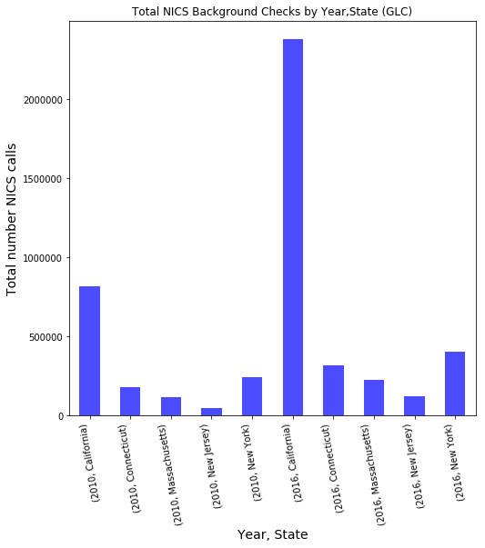

```python
glc_nics_totals = glc.groupby(['year', 'state']).sum()['totals']
glc_nics_totals.plot(kind='bar', title='Total NICS Background Checks by Year,State (GLC)', color='blue', alpha=0.7, figsize=(8,8))
plt.title('Total NICS Background Checks by Year,State (GLC)', fontsize=16)
plt.xticks(rotation=100)
plt.xlabel('Year, State', fontsize=14)
plt.ylabel('Total number NICS calls', fontsize=14)
```

```
Text(0,0.5,'Total number NICS calls')
```

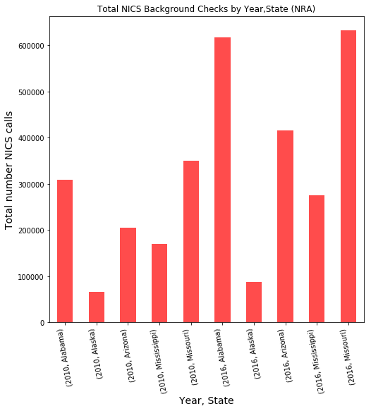

```python
nra_nics_totals = nra.groupby(['year', 'state']).sum()['totals']
nra_nics_totals.plot(kind='bar', color='red', alpha=0.7, figsize=(8,8))
plt.title('Total NICS Background Checks by Year,State (NRA)', fontsize=16)
plt.xticks(rotation=100)
plt.xlabel('Year, State', fontsize=14)
plt.ylabel('Total number NICS calls', fontsize=14)
```

We notice immediately that in absolute terms, California dwarfs all other states - regardless of regulatory environment - in the number of background checks executed against NICS in 2016 (at almost 2.4M). With this in mind we are going to need to introduce some population figures from the census data to come up with a better metric for considering NICS checks relative to the state population.

```python
df_census_eda = pd.read_csv('census_eda.csv') #reload the `census_eda` dataframe that we will be using

#transpose the 2010/16 NICS totals so that the resulting dataframes can be inserted as rows into the census dataframe
year_nics_totals = nra_nics_totals.to_frame() #convert series to dataframe
nics_totals_2010 = year_nics_totals.query('year == "2010"') #query each dataframe by year to create stacked rows
nics_totals_2010.reset_index(inplace=True)
nics_totals_2016 = year_nics_totals.query('year == "2016"')
nics_totals_2016.reset_index(inplace=True)
#pivot the state rows into columns and make the totals the values, index by year
nics_totals_2010 = nics_totals_2010.pivot(index='year', columns='state', values='totals')
nics_totals_2016 = nics_totals_2016.pivot(index='year', columns='state', values='totals')
nics_totals_nra = nics_totals_2010.append(nics_totals_2016)
nics_totals_nra #check it out
```

| state year | Alabama | Alaska | Arizona | Mississippi | Missouri |
| --- | --- | --- | --- | --- | --- |
| 2010 | 308607 | 65909 | 206050 | 169873 | 349672 |
| 2016 | 616947 | 87647 | 416279 | 276161 | 632319 |

```python
#transpose the 2010/16 NICS totals so that the resulting dataframes can be inserted as rows into the census dataframe
year_nics_totals = glc_nics_totals.to_frame()
nics_totals_2010 = year_nics_totals.query('year == "2010"')
nics_totals_2010.reset_index(inplace=True)
nics_totals_2016 = year_nics_totals.query('year == "2016"')
nics_totals_2016.reset_index(inplace=True)

nics_totals_2010 = nics_totals_2010.pivot(index='year', columns='state', values='totals')
nics_totals_2016 = nics_totals_2016.pivot(index='year', columns='state', values='totals')
nics_totals_glc = nics_totals_2010.append(nics_totals_2016)
nics_totals_glc #check it out
```

| state year | California | Connecticut | Massachusetts | New Jersey | New York |
| --- | --- | --- | --- | --- | --- |
| 2010 | 816399 | 179595 | 115904 | 50522 | 241495 |
| 2016 | 2377167 | 317692 | 226212 | 121853 | 404772 |

Use the `concat` function to 'glue' these 2 dataframes together to form the single row for append/insertion into the census data file, and reset the index so that the number of columns aligns.

```python
nics_totals_eda = pd.concat([nics_totals_nra, nics_totals_glc], axis=1, join_axes=[nics_totals_nra.index])
nics_totals_eda.reset_index(inplace=True)
nics_totals_eda #check it out
```

| state | year | Alabama | Alaska | Arizona | Mississippi | Missouri | California | Connecticut | Massachusetts | New Jersey | New York |
| --- | --- | --- | --- | --- | --- | --- | --- | --- | --- | --- | --- |
| 0 | 2010 | 308607 | 65909 | 206050 | 169873 | 349672 | 816399 | 179595 | 115904 | 50522 | 241495 |
| 1 | 2016 | 616947 | 87647 | 416279 | 276161 | 632319 | 2377167 | 317692 | 226212 | 121853 | 404772 |

Change the first col to 'Fact' so that it will align with the `census_eda`. Also change the contents to descriptive string values.

```python
nics_totals_eda.iloc[0,0] = 'Total NICS calls 2010'
nics_totals_eda.iloc[1,0] = 'Total NICS calls 2016'
nics_totals_eda = nics_totals_eda.rename(columns = {'year':'Fact'})
nics_totals_eda
```

| state | Fact | Alabama | Alaska | Arizona | Mississippi | Missouri | California | Connecticut | Massachusetts | New Jersey | New York |
| --- | --- | --- | --- | --- | --- | --- | --- | --- | --- | --- | --- |
| 0 | Total NICS calls 2010 | 308607 | 65909 | 206050 | 169873 | 349672 | 816399 | 179595 | 115904 | 50522 | 241495 |
| 1 | Total NICS calls 2016 | 616947 | 87647 | 416279 | 276161 | 632319 | 2377167 | 317692 | 226212 | 121853 | 404772 |

```python
#Confirm the column names are identical across the 2 dataframes prior to appending
nics_totals_eda.columns == df_census_eda.columns #WHAT?!  I need to make a correction and re-order 2 of the cols
```

```
array([ True,  True,  True,  True, False, False,  True,  True,  True,
        True,  True])
```

```python
nics_cols = nics_totals_eda.columns.tolist()
nics_cols = ['Fact',
 'Alabama',
 'Alaska',
 'Arizona',
 'Missouri',
 'Mississippi',
 'California',
 'Connecticut',
 'Massachusetts',
 'New Jersey',
 'New York']
nics_totals_eda = nics_totals_eda[nics_cols]
nics_totals_eda.columns == df_census_eda.columns #recheck that the columns are aligned
```

```
array([ True,  True,  True,  True,  True,  True,  True,  True,  True,
        True,  True])
```

Finally, append the `nics_totals_eda` to the `df_census_eda` dataframe, and save to csv, so that I can continue with my EDA.

```python
df_eda = df_census_eda.append(nics_totals_eda)
df_eda.to_csv('df_eda_final.csv', index=False)
```

```python
df_eda = pd.read_csv('df_eda_final.csv') #reload the dataframe that we are going to use for our analysis
```

## Exploratory Data Analysis

### Explore NICS background check calls in the sample set relative to state populations by creating new statistics to illustrate comparisons and trends across 2010 and 2016

As an additional preparatory step, I think it is useful to limit the census population in each state to those that can lawfully purchase firearms. For the purposes of this analysis, and not taking into account legislative changes that may be in the works, we are going to characterize this as the portion of the population that is 18 years and above in age.

```python
states_col = ['Alabama','Alaska','Arizona','Missouri','Mississippi','California','Connecticut','Massachusetts','New Jersey', 'New York']

#create a series to hold the firearm purchase-age population for all sample states in 2016
df_over18_pop16 = (df_eda.loc[0,states_col]) * (1 - df_eda.loc[38, states_col]) #(1 - % persons under 18yrs)
df_over18_pop16.astype(int)
```

```
Alabama           3764194
Alaska             554936
Arizona           5302269
Missouri          4703796
Mississippi       2268443
California       30144013
Connecticut       2821820
Massachusetts     5435799
New Jersey        6958796
New York         15559287
dtype: int64
```

```python
#check the shape of this series to align it to the NICS series
df_over18_pop16.shape
```

```
(10,)
```

```python
#create a series to hold the firearm purchase-age population for all sample states in 2010
df_over18_pop10 = (df_eda.loc[2, states_col]) * (1 - df_eda.loc[39, states_col]) #(1 - % persons under 18yrs)
df_over18_pop10.astype(int)
```

```
Alabama           3646938
Alaska             522730
Arizona           4762052
Missouri          4563562
Mississippi       2210636
California       27940467
Connecticut       2755628
Massachusetts     5126793
New Jersey        6725798
New York         15056785
dtype: int64
```

```python
nics_2010 = df_eda.loc[64, states_col] #create series with the rows for 'Total NICS calls 2016/10'
nics_2016 = df_eda.loc[65, states_col]
```

```python
#create dataframe with .concat that combines the adult population with the NICS calls for 2010
pop10_over_nics = pd.concat([df_over18_pop10, nics_2010], axis=1).reset_index()
pop10_over_nics.rename(columns = {'index':'state', 0 :'adult_population', 64 :'NICS_calls'}, inplace=True)
```

```python
pop10_over_nics.info()
```

[output not shown]

```python
cols = pop10_over_nics.columns.drop('state')  #convert both the adult_population and NICS_calls to numbers
pop10_over_nics[cols] = pop10_over_nics[cols].apply(pd.to_numeric).astype(int)
```

```python
#calculate 2 new statistics that capture the NICS calls per 1000 population, and the number of adults for every NICS call in 2010
pop10_over_nics['pop_per_call'] = (pop10_over_nics['adult_population'] / pop10_over_nics['NICS_calls']).round(2)
pop10_over_nics['calls_per_1000'] = (pop10_over_nics['NICS_calls'] / (pop10_over_nics['adult_population'] / 1000)).round(2)
pop10_over_nics #check it out
```

[output not shown]

Below I have plotted all 10 states NICS calls per 1000 adult population, and below that is the quotient of adults per NICS call for all states in 2010.

```
Text(0,0.5,'NICS calls')
```

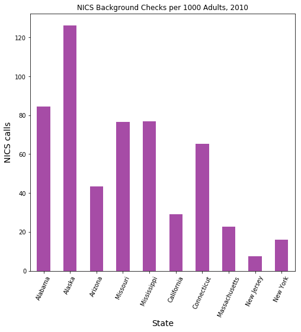

```python
NICS_1000_2010 = pop10_over_nics[['state', 'calls_per_1000']]
NICS_1000_2010.set_index('state').plot(kind='bar', color='purple', legend=False, alpha=0.7, figsize=(8,8))
plt.title('NICS Background Checks per 1000 Adults, 2010', fontsize=16)
plt.xticks(rotation=65)
plt.xlabel('State', fontsize=14)
plt.ylabel('NICS calls', fontsize=14)
```

Notice the extremely high number of NICS calls per 1000 adults in Alaska, as well as the generally higher number of calls between the 2 subsets of states: NRA `index 0:4` and GLC `index 5:9`. The exception here is Arizona and Connecticut, which display the opposite of the expectation. We would need to dig deeper into other aspects of the FBI/NICS structure in each of these states to understand if there are differences to how the systems are administered.

```
Text(0,0.5,'Adults per NICS call')
```

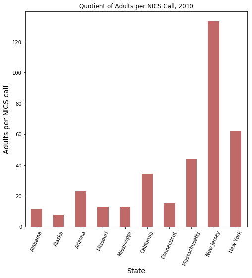

```python
NICS_pop_2010 = pop10_over_nics[['state', 'pop_per_call']]
NICS_pop_2010.set_index('state').plot(kind='bar', color='brown', legend=False, alpha=0.7, figsize=(8,8))
plt.title('Quotient of Adults per NICS Call, 2010', fontsize=16)
plt.xticks(rotation=65)
plt.xlabel('State', fontsize=14)
plt.ylabel('Adults per NICS call', fontsize=14)
```

This bar graph essentially displays the inverse of the one above. Those states with elevated levels of NICS calls per 1000 adult population display lower levels of adult population per NICS call. Again we note the exception between AZ and CT. New Jersey renders an extremely elevated quotient of population to NICS call at 133 adult persons per background check in 2010.

```python
#create dataframe with .concat that combines the adult population with the NICS calls for 2016
pop16_over_nics = pd.concat([df_over18_pop16, nics_2016], axis=1).reset_index()
pop16_over_nics.rename(columns = {'index':'state', 0 :'adult_population', 65 :'NICS_calls'}, inplace=True)
```

```python
cols = pop16_over_nics.columns.drop('state')  #convert both the adult_population and NICS_calls to numbers
pop16_over_nics[cols] = pop16_over_nics[cols].apply(pd.to_numeric).astype(int)
pop16_over_nics #check it out
```

|  | state | adult_population | NICS_calls |
| --- | --- | --- | --- |
| 0 | Alabama | 3764194 | 616947 |
| 1 | Alaska | 554936 | 87647 |
| 2 | Arizona | 5302269 | 416279 |
| 3 | Missouri | 4703796 | 632319 |
| 4 | Mississippi | 2268443 | 276161 |
| 5 | California | 30144013 | 2377167 |
| 6 | Connecticut | 2821820 | 317692 |
| 7 | Massachusetts | 5435799 | 226212 |
| 8 | New Jersey | 6958796 | 121853 |
| 9 | New York | 15559287 | 404772 |

```python
pop16_over_nics['pop_per_call'] = (pop16_over_nics['adult_population'] / pop16_over_nics['NICS_calls']).round()
pop16_over_nics['calls_per_1000'] = (pop16_over_nics['NICS_calls'] / (pop16_over_nics['adult_population'] / 1000)).round()
pop16_over_nics #check it out
```

|  | state | adult_population | NICS_calls | pop_per_call | calls_per_1000 |
| --- | --- | --- | --- | --- | --- |
| 0 | Alabama | 3764194 | 616947 | 6.0 | 164.0 |
| 1 | Alaska | 554936 | 87647 | 6.0 | 158.0 |
| 2 | Arizona | 5302269 | 416279 | 13.0 | 79.0 |
| 3 | Missouri | 4703796 | 632319 | 7.0 | 134.0 |
| 4 | Mississippi | 2268443 | 276161 | 8.0 | 122.0 |
| 5 | California | 30144013 | 2377167 | 13.0 | 79.0 |
| 6 | Connecticut | 2821820 | 317692 | 9.0 | 113.0 |
| 7 | Massachusetts | 5435799 | 226212 | 24.0 | 42.0 |
| 8 | New Jersey | 6958796 | 121853 | 57.0 | 18.0 |
| 9 | New York | 15559287 | 404772 | 38.0 | 26.0 |

```
Text(0,0.5,'NICS calls')
```

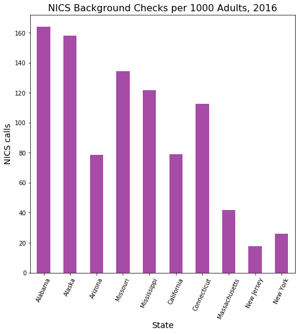

```python
NICS_1000_2016 = pop16_over_nics[['state', 'calls_per_1000']]
NICS_1000_2016.set_index('state').plot(kind='bar', color='purple', legend=False, alpha=0.7, figsize=(8,8))
plt.title('NICS Background Checks per 1000 Adults, 2016', fontsize=16)
plt.xticks(rotation=65)
plt.xlabel('State', fontsize=14)
plt.ylabel('NICS calls', fontsize=14)
```

In this graph depicting the NICS calls per 1000 adults across states in 2016 we notice that there is generally a much higher number of NICS calls/background checks *across the board* with a significant increases in both Alabama `200%` and California `~300%` between 2010 and 2016. California is actually at the same /1000 level of NICS calls as a notable 'gun friendly' state in Arizona, at 79 per 1000. Connecticut's /1000 level also remains elevated relative to other highly regulated states in the GLC category and actually saw a near `75%` increase in NICS calls per 1000 population between 2010 & 2016.

These observations of general increases in background checks could quite possibly be due to more stringent enforcement of existing laws and regulations in these states during the period from 2010 to 2016. Or there may be significant differences between states in how parties are required to utilize the Federal NICS database for firearms transactions. We would need further information on states' gun rights laws and how these laws integrate with Federal regulations, as well as some idea of how enforcement is carried out at the state level.

If we relate these NICS Background Checks /100 graphs back to the `Total NICS Background Checks by Year,State (NRA)&(GLC)` from earlier in the notebook, we can see that absolute values of calls to the NICS database are pretty irrelevant without the requisite population data to put the database usage into perspective.

```
Text(0,0.5,'Adults per NICS call')
```

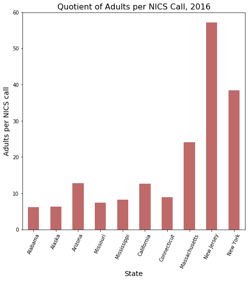

```python
NICS_pop_2016 = pop16_over_nics[['state', 'pop_per_call']]
NICS_pop_2016.set_index('state').plot(kind='bar', color='brown', legend=False, alpha=0.7, figsize=(8,8))
plt.title('Quotient of Adults per NICS Call, 2016', fontsize=16)
plt.xticks(rotation=65)
plt.xlabel('State', fontsize=14)
plt.ylabel('Adults per NICS call', fontsize=14)
```

The graph of the quotient of adults per NICS call across states in 2016 is similar to the same graph plotted for 2010. The higher the number of NICS calls relative to the state's adult population, the lower the quotient. So we see states like MA, NJ and NY to the right of the graph with higher adult quotients, since they see lower numbers of NICS background checks, and presumably less federally regulated transactions involving firearms.

### Continue to explore several key population characteristics in light of previously examining the level of NICS activity in the sample states.

> **Tip**: Now that you've trimmed and cleaned your data, you're ready to move on to exploration. Compute statistics and create visualizations with the goal of addressing the research questions that you posed in the Introduction section. It is recommended that you be systematic with your approach. Look at one variable at a time, and then follow it up by looking at relationships between variables.

In this section we'll explore some additional aggregated census variables by state and produce visualizations that compare to the NICS data from earlier.

```python
#Examine percent of state population with at least a college degree: series below
coll_degree = df_eda.loc[57,states_col]
#coll_degree.astype(float).round(2)
coll_degree = coll_degree.reset_index()
coll_degree.shape
```

```
(10, 2)
```

```python
coll_degree.rename(columns = {'index':'state', 57 :'percent_degree'}, inplace=True) #rename cols
```

```python
coll_degree
```

|  | state | percent_degree |
| --- | --- | --- |
| 0 | Alabama | 0.235 |
| 1 | Alaska | 0.28 |
| 2 | Arizona | 0.275 |
| 3 | Missouri | 0.271 |
| 4 | Mississippi | 0.207 |
| 5 | California | 0.314 |
| 6 | Connecticut | 0.376 |
| 7 | Massachusetts | 0.405 |
| 8 | New Jersey | 0.368 |
| 9 | New York | 0.342 |

```python
glc_states = np.zeros(shape=(5,1))
glc_states = np.repeat('GLC', 5)
df_glc_states = pd.DataFrame(glc_states) #convert series to df

nra_states = np.zeros(shape=(5,1))
nra_states = np.repeat('NRA', 5)
df_nra_states = pd.DataFrame(nra_states) #convert series to df
```

```python
coll_degree = pd.concat([coll_degree, df_nra_states], axis=1)
```

```python
coll_degree.rename(columns = {0: 'regulation'}, inplace=True) #rename col
coll_degree.loc[5:9, 'regulation'] = glc_states #fill in last 5 rows with GLC designation
```

```python
coll_degree['percent_degree'] = coll_degree['percent_degree'].astype(float).round(2)
coll_degree.info()
```

```
<class 'pandas.core.frame.DataFrame'>
RangeIndex: 10 entries, 0 to 9
Data columns (total 3 columns):
state             10 non-null object
percent_degree    10 non-null float64
regulation        10 non-null object
dtypes: float64(1), object(2)
memory usage: 320.0+ bytes
```

```python
coll_degree #inspect dataframe
```

|  | state | percent_degree | regulation |
| --- | --- | --- | --- |
| 0 | Alabama | 0.24 | NRA |
| 1 | Alaska | 0.28 | NRA |
| 2 | Arizona | 0.28 | NRA |
| 3 | Missouri | 0.27 | NRA |
| 4 | Mississippi | 0.21 | NRA |
| 5 | California | 0.31 | GLC |
| 6 | Connecticut | 0.38 | GLC |
| 7 | Massachusetts | 0.40 | GLC |
| 8 | New Jersey | 0.37 | GLC |
| 9 | New York | 0.34 | GLC |

The box plots below reveal that the proportion of the population with a college degree is higher in states with tougher gun control laws, as recognized by the Giffords Law Center (GLC). The distribution of the 5 states in this category in nearly normal. By contrast, the 5 states recognized as extremely gun rights friendly by the National Rifle Association (NRA) have much lower rates of college degrees among the population and the data is skewed to the lower end by Mississippi's 21%.

[figure not shown]

```python
bp = coll_degree[['regulation', 'percent_degree']].boxplot(by='regulation', showmeans=True, meanline=True, grid=False, figsize=(12,8))
plt.title('Distribution of the Percent with College Degree by Gun Regulation Indicator(2016) \n', fontsize=16)
plt.xlabel('States Ranked Top 5 by:', fontsize=14)
plt.ylabel('Percentages of State Population with College Degree', fontsize=14);
```

Below we will examine the poverty rate in particular states and indicate their NICS calls per 1000 adult population as part of the chart descriptions.

As a disclaimer: we do not know for which year the the 'Percent of persons in poverty' figures are for in the provided census data, but we will display the figure in relation to the 2016 NICS data.

```python
#Create 'poverty' data series across the 10 sample states
poverty = df_eda.loc[62,states_col]
poverty.astype(float)
poverty = poverty.reset_index()
poverty.shape #check shape with index reset
```

```
(10, 2)
```

```python
poverty.rename(columns = {'index':'state', 62 :'percent_poverty'}, inplace=True) #rename cols
```

Adding the NRA & GLC indicators to our dataframe for use in creating visualizations.

```python
poverty = pd.concat([poverty, df_nra_states], axis=1) #add col with NRA designation for the first 5 states
```

```python
poverty.rename(columns = {0: 'regulation'}, inplace=True) #rename col
poverty.loc[5:9, 'regulation'] = glc_states #fill in last 5 rows with GLC designation
```

```python
poverty['percent_poverty'] = poverty['percent_poverty'].astype(float).round(2)
poverty.info() #check df object types
```

```
<class 'pandas.core.frame.DataFrame'>
RangeIndex: 10 entries, 0 to 9
Data columns (total 3 columns):
state              10 non-null object
percent_poverty    10 non-null float64
regulation         10 non-null object
dtypes: float64(1), object(2)
memory usage: 320.0+ bytes
```

```python
poverty #check out the new df
```

[output not shown]

```python
(poverty > 0).all(1) #after receiving 'ValueError:' while creating multiple pie charts, check that all values positive
```

```
0    True
1    True
2    True
3    True
4    True
5    True
6    True
7    True
8    True
9    True
dtype: bool
```

From the below boxplots we can recognize that the GLC states generally have a lower mean poverty rate with a more tightly packed dataset, while the NRA states have a higher mean poverty rate with much more variance at the outer bounds.

[figure not shown]

```python
bp = poverty[['regulation', 'percent_poverty']].boxplot(by='regulation', showmeans=True, meanline=True, grid=False, figsize=(12,8))
plt.title('Distribution of the Percent Living in Poverty by Gun Regulation Indicator(2016) \n', fontsize=16)
plt.xlabel('States Ranked Top 5 by:', fontsize=14)
plt.ylabel('Percentages of State Population Living in Poverty', fontsize=14);
```

2 of the states with the highest percent of population living below the federal poverty line happen to be `NRA` states where the level of NICS calls per 1000 population are also elevated. Let's interpret this with pie chart visualizations to display proportionality.

```python
poverty_pie = poverty.drop('regulation', axis=1)
poverty_pie #check out df
```

|  | state | percent_poverty |
| --- | --- | --- |
| 0 | Alabama | 0.171 |
| 1 | Alaska | 0.099 |
| 2 | Arizona | 0.164 |
| 3 | Missouri | 0.140 |
| 4 | Mississippi | 0.208 |
| 5 | California | 0.143 |
| 6 | Connecticut | 0.098 |
| 7 | Massachusetts | 0.104 |
| 8 | New Jersey | 0.104 |
| 9 | New York | 0.147 |

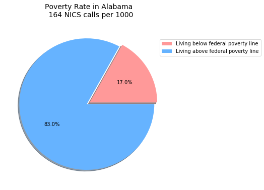

```python
names = ['Living below federal poverty line', 'Living above federal poverty line']
poverty_slice = poverty_pie.query('state == "Alabama"')['percent_poverty'][0].round(2)
rich_slice = 1 - poverty_slice
values = [poverty_slice, rich_slice]
colors=('#ff9999', '#66b3ff')
explode=(0, 0.05)

plt.subplots(figsize=(6,6))
plt.pie(x=values, colors=colors, explode=explode, shadow=True, autopct='%1.1f%%')
plt.title('Poverty Rate in Alabama \n 164 NICS calls per 1000', fontsize=14)
plt.legend(labels=names, bbox_to_anchor=(0.9,0.9));
```

[figure not shown]

```python
names = ['Living below federal poverty line', 'Living above federal poverty line']
poverty_slice = poverty_pie.query('state == "Mississippi"')['percent_poverty'][4].round(2)
rich_slice = 1 - poverty
values = [poverty_slice, rich_slice]
colors=('#ff9999', '#66b3ff')
explode=(0, 0.05)

plt.subplots(figsize=(6,6))
plt.pie(x=values, colors=colors, explode=explode, shadow=True, autopct='%1.1f%%')
plt.title('Poverty Rate in Mississippi \n 122 NICS calls per 1000', fontsize=14)
plt.legend(labels=names, bbox_to_anchor=(0.9,0.9));
```

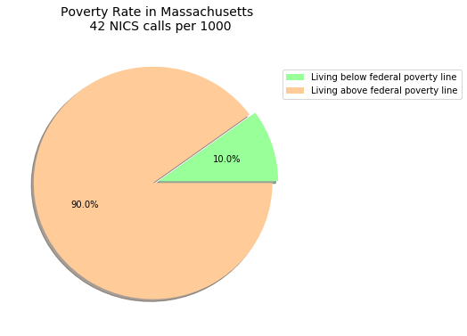

```python
names = ['Living below federal poverty line', 'Living above federal poverty line']
poverty_slice = poverty_pie.query('state == "Massachusetts"')['percent_poverty'][7].round(2)
rich_slice = 1 - poverty_slice
values = [poverty_slice, rich_slice]
colors=('#99ff99', '#ffcc99')
explode=(0, 0.05)

plt.subplots(figsize=(6,6))
plt.pie(x=values, colors=colors, explode=explode, shadow=True, autopct='%1.1f%%')
plt.title('Poverty Rate in Massachusetts \n 42 NICS calls per 1000', fontsize=14)
plt.legend(labels=names, bbox_to_anchor=(0.9,0.9));
```

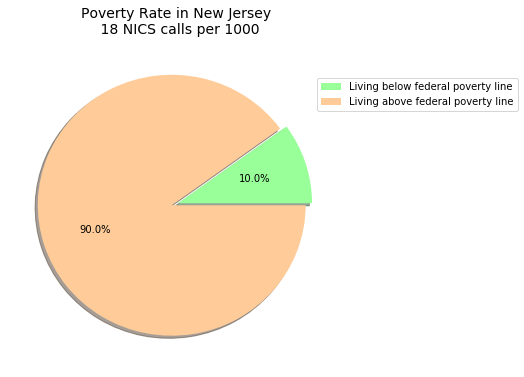

```python
names = ['Living below federal poverty line', 'Living above federal poverty line']
poverty_slice = poverty_pie.query('state == "New Jersey"')['percent_poverty'][8].round(2)
rich_slice = 1 - poverty_slice
values = [poverty_slice, rich_slice]
colors=('#99ff99', '#ffcc99')
explode=(0, 0.05)

plt.subplots(figsize=(6,6))
plt.pie(x=values, colors=colors, explode=explode, shadow=True, autopct='%1.1f%%')
plt.title('Poverty Rate in New Jersey \n 18 NICS calls per 1000', fontsize=14)
plt.legend(labels=names, bbox_to_anchor=(0.9,0.9));
```

## Conclusions

> In conclusion we have become aware, by examining the FBI NICS and census data across the states selected for our analysis, that there are dinstinct population characteristics between those states with conservative gun rights lawsm and those with liberal gun control laws. This does not by any means imply causation! Nor does it necessarily demonstrate any correlation between the population traits chosen for this analysis -- proportion of population with a college degree and proportion of the population living below the Federal povery line -- but we may observe that these states do indeed display stark differences in these particular variables.

> Some of the limitations included a lack of accurate date information for the census data. For instance, we do not know for which year the percent in poverty or percent with college degree are for. Nor do we have any historical data to identify changes or trends over time. Also, the census data often provides ranges of years (2011 - 2015) that made them difficult to interpret ie. are these mean values for this time period? To further improve this analysis, and given more time to do so, it would be prudent to seek out better updated census data from the census.gov website.